# Statistical Programming Skills

Create a function that, given a mass (kg) and height (m), returns the BMI of the individual

```python
#the first values are the height of the person (m), whereas the second values are the weight (kg)
height_weight_values = [(1.89,87), (1.85,None), (1.95,104), (1.49,61), (1.89,104), (1.47,92), (1.54,111), (1.74,90), (1.69,None), (1.95,81)]

# Creating a function to calculate the BMI for a person, given the weight, and the height
def calculate_bmi(height, weight):
    # If the height, or Weight values are 'None', error is returned. So they are not processed.
    if height == None or weight == None:
        return(None)
    else:
        bmi = weight/(height ** 2)
        return(('%.2f' % bmi)) # return bmi to 2 decimal places

# Running a test with a height of 1.7m, and a weight of 50kg
print(f"Your BMI is: {calculate_bmi(1.7, 50)}")
# Returns 17.30

# Additional test if one of the values is 'None'
print(f"Your BMI is: {calculate_bmi(1.7, None)}")
# Returns 'None'
```

```
Your BMI is: 17.30
Your BMI is: None
```

Iterate over the height-weight values list to calculate the BMI using the calculate_bmi function

```python
bmi_values = [] # stores the bmi values after processing height and weight

"""Function to calculate the BMI, given height and weight"""
def calculate_bmi_2(height, weight):
    if height == None or weight == None:
        return(None)
    else:
        bmi = weight/(height ** 2)
        return(float('%.2f' % bmi)) # return bmi to 2 decimal places. float required, otherwise string is returned

"""Extracting the height and weight from each element in the height_weight_values"""
for element in height_weight_values:
    height = element[0]
    weight = element[1]
    bmi_values.append(calculate_bmi_2(height, weight))

"""Returning results"""
print(bmi_values)
```

```
[24.36, None, 27.35, 27.48, 29.11, 42.57, 46.8, 29.73, None, 21.3]
```

Classify the BMI values into categories.

Where a BMI of:

- <18.5 is underweight.
- 18.5< bmi >25 is a healthy BMI.
- 25< bmi < 30 is overweight.
- 30< is obese.

```python
"""Finding the BMI category given a BMI"""
def lookup_bmi_category(bmi_value):
    if bmi_value == None:
        return(None)
    elif bmi_value < 18.5:
        return(0) # Underweight
    elif 18.5 < bmi_value < 25:
        return(1) # Healthy weight
    elif 25 < bmi_value < 30:
        return(2) # Overweight
    elif bmi_value > 30:
        return(3) # Obese
    else:
        return(None)

bmi = float(input("Enter your BMI: ")) # Taking user input for BMI
bmi_category = lookup_bmi_category(bmi) # Calls lookup_bmi_category function, parses 'bmi'
print(f"Your BMI category is: {bmi_category}") # Prints a string, followed by the corresponding BMI category
```

```
Enter your BMI: 56
Your BMI category is: 3
```

Provide tests for the returned BMI categories.

```python
# Testing the categories returned
print(lookup_bmi_category(34) == 3)
print(lookup_bmi_category(14) == 0)
print(lookup_bmi_category(70) == 3)
print(lookup_bmi_category(24) == 1)
```

```
True
True
True
True
```

Iterate over the bmi_values list, and categorise each BMI reading.

```python
bmi_categories = []
for value in bmi_values:
    bmi_categories.append(lookup_bmi_category(value))

print(bmi_categories)
```

```
[1, None, 2, 2, 2, 3, 3, 2, None, 1]
```

Iterate over the bmi_categories list, and highlight the BMI values that are classified as obese.

```python
obese_list = []

for category in bmi_categories:
    if category == 3:
        obese_list.append(True)
    elif category == 1 or category == 2:
        obese_list.append(False)
    else:
        obese_list.append(None)

print(obese_list)
```

```
[False, None, False, False, False, True, True, False, None, False]
```

Return:

- The total number of people in the list;
- Number of obese people;
- Number of non-obese people.

```python
# Total number of people in obese_list
total_num = len(obese_list)

# Number of obese people in obese_list
obese_num = 0
not_obese = 0
for value in obese_list:
    if value == True:
        obese_num += 1
    elif value == False:
        not_obese += 1

print(f"Total number of people in obese_list: {total_num}")
print(f"Number of obese people in obese_list: {obese_num}")
print(f"Number of not obese people in obese_list: {not_obese}")
```

```
Total number of people in obese_list: 10
Number of obese people in obese_list: 2
Number of not obese people in obese_list: 6
```

By slicing the obese_list, return:

- The first half;
- The second half;
- The whole list apart from the first and last three values.

```python
# Printing the first half of obese_list
print(obese_list[:5])

# Printing the latter half of obese_list
print(obese_list[5:])

# Printing all except first 3, and last 3 values in obese_list
print(obese_list[3:-3])
```

```
[False, None, False, False, False]
[True, True, False, None, False]
[False, False, True, True]
```

Import Pandas, and load the dataset

```python
# importing pandas
import pandas as pd

# setting directory
directory = ""

# loading dataset, and assigning to a variable
df = pd.read_csv(f"{directory}\\heights-weights-bmis.csv")
```

Read the first three rows of the loaded dataset

```python
# returning the first three rows
df[:3]
```

|  | Gender | Height | Weight | BMI | Category |
| --- | --- | --- | --- | --- | --- |
| 0 | Male | NaN | 96.0 | NaN | NaN |
| 1 | Male | 189.0 | 87.0 | 24.36 | 1.0 |
| 2 | Female | 185.0 | 110.0 | 32.14 | 3.0 |

Return the last three rows of the loaded dataset

```python
# returning the last three rows
df[-3:]
```

|  | Gender | Height | Weight | BMI | Category |
| --- | --- | --- | --- | --- | --- |
| 497 | Female | 141.0 | 136.0 | 68.41 | 3.0 |
| 498 | Male | 150.0 | 95.0 | 42.22 | 3.0 |
| 499 | Male | 173.0 | 131.0 | 43.77 | 3.0 |

Return the column names and their corresponding data types

```python
# returning column names and data types
df.dtypes
```

```
Gender       object
Height      float64
Weight      float64
BMI         float64
Category    float64
dtype: object
```

Provide descriptive statistics for the dataframe

```python
# descriptive statistics for the dataframe
df.describe()
```

|  | Height | Weight | BMI | Category |
| --- | --- | --- | --- | --- |
| count | 499.000000 | 498.000000 | 497.000000 | 497.000000 |
| mean | 169.935872 | 105.887550 | 37.717928 | 2.394366 |
| std | 16.390684 | 32.356842 | 13.970653 | 0.955359 |
| min | 140.000000 | 50.000000 | 12.750000 | 0.000000 |
| 25% | 156.000000 | 80.000000 | 27.100000 | 2.000000 |
| 50% | 170.000000 | 105.500000 | 36.950000 | 3.000000 |
| 75% | 184.000000 | 136.000000 | 46.290000 | 3.000000 |
| max | 199.000000 | 160.000000 | 78.850000 | 3.000000 |

Return each value found within the category column, and return the number of times that value is found.

```python
# generating a pandas series, and applying a count method
pd.Series(df["Category"]).value_counts()
```

```
3.0    329
2.0     69
1.0     65
0.0     34
Name: Category, dtype: int64
```

Return the first 5 rows of the category column.

```python
# printing the first 5 values of the 'Category' column
print(df.Category.iloc[:5])
```

```
0    NaN
1    1.0
2    3.0
3    2.0
4    2.0
Name: Category, dtype: float64
```

Return the first 10 gender and BMI rows for which the BMI category is 3.

```python
# printing Gender, and BMI, for the first 10 rows with a category of 3
df.loc[df.Category == 3, ["Gender", "BMI"]].head(10)
```

|  | Gender | BMI |
| --- | --- | --- |
| 2 | Female | 32.14 |
| 6 | Male | 42.57 |
| 7 | Male | 46.80 |
| 9 | Female | 36.06 |
| 11 | Female | 31.64 |
| 15 | Female | 45.71 |
| 16 | Female | 44.63 |
| 17 | Male | 65.82 |
| 18 | Male | 69.93 |
| 19 | Male | 46.98 |

Return the height and weight rows for which the gender is male, and the height of the individual is greater than 195cm.

```python
# Question 2.6

# print the height, and weight of males with a height greater than 195cm
df.loc[(df.Gender == "Male") & (df.Height > 195), ["Height", "Weight"]]
```

|  | Height | Weight |
| --- | --- | --- |
| 54 | 196.0 | 116.0 |
| 85 | 198.0 | 50.0 |
| 94 | 197.0 | 119.0 |
| 100 | 199.0 | 156.0 |
| 145 | 197.0 | 125.0 |
| 160 | 199.0 | 99.0 |
| 174 | 197.0 | 149.0 |
| 308 | 196.0 | 69.0 |
| 351 | 197.0 | 88.0 |
| 469 | 198.0 | 109.0 |
| 488 | 198.0 | 136.0 |

Group the dataframe by gender and BMI category, then return the mean of the height, weight, and BMI.

```python
# Question 2.7

# group by gender, and category. Return the mean height, weight, and BMI
df.groupby(["Gender", "Category"])[["Height", "Weight", "BMI"]].mean()
```

| Gender | Category | Height | Weight | BMI |
| --- | --- | --- | --- | --- |
| Female | 0.0 | 187.076923 | 55.153846 | 15.840769 |
|  | 1.0 | 171.894737 | 65.000000 | 21.913158 |
|  | 2.0 | 177.027027 | 86.702703 | 27.462973 |
|  | 3.0 | 167.138554 | 123.192771 | 44.772048 |
| Male | 0.0 | 186.095238 | 57.380952 | 16.578571 |
|  | 1.0 | 177.259259 | 71.259259 | 22.582222 |
|  | 2.0 | 175.406250 | 85.750000 | 27.671250 |
|  | 3.0 | 165.122699 | 122.196319 | 45.494110 |

Return the rows which have a missing height, or weight, value.

```python
# creating a new dataframe which declares missing values as "True"
missing_data = df.isna()

# if the value is True, the data is missing; therefore, return it
missing_data.loc[(missing_data.Weight == True) | (missing_data.Height == True)]
```

|  | Gender | Height | Weight | BMI | Category |
| --- | --- | --- | --- | --- | --- |
| 0 | False | True | False | True | True |
| 41 | False | False | True | True | True |
| 157 | False | False | True | True | True |

Create two plots of the BMI dataframe.

```python
# importing matplotlib
import matplotlib.pyplot as plt

# importing numpy
import numpy as np
```

```python
"""Cleaning Data"""

# creating a new dataframe with the column means by gender, to be used to replace missing height and weight values
height_weight_means = df.groupby("Gender").transform("mean")
height_weight_means.head()
```

|  | Height | Weight | BMI | Category |
| --- | --- | --- | --- | --- |
| 0 | 169.631148 | 106.094262 | 38.102428 | 2.386831 |
| 1 | 169.631148 | 106.094262 | 38.102428 | 2.386831 |
| 2 | 170.227451 | 105.688976 | 37.350079 | 2.401575 |
| 3 | 170.227451 | 105.688976 | 37.350079 | 2.401575 |
| 4 | 169.631148 | 106.094262 | 38.102428 | 2.386831 |

```python
# creating a new dataframe with the replaced missing values, in order to leave the original dataframe, original

clean_df = df

# selecting the height and weight columns to write information to, and selecting them again to replace missing values
clean_df.loc[:,["Height", "Weight"]] = df.loc[:,["Height", "Weight"]].fillna(height_weight_means)

# printing the first 5 rows from the new dataframe
clean_df.head()
```

|  | Gender | Height | Weight | BMI | Category |
| --- | --- | --- | --- | --- | --- |
| 0 | Male | 169.631148 | 96.0 | NaN | NaN |
| 1 | Male | 189.000000 | 87.0 | 24.36 | 1.0 |
| 2 | Female | 185.000000 | 110.0 | 32.14 | 3.0 |
| 3 | Female | 195.000000 | 104.0 | 27.35 | 2.0 |
| 4 | Male | 149.000000 | 61.0 | 27.48 | 2.0 |

```python
# now that the missing height, and weight values are dealt with, we can replace the missing BMI values

# write pandas height and weight columns to individual lists
height_list = clean_df["Height"].tolist()
weight_list = clean_df["Weight"].tolist()
bmi_list = [] # stores output BMI values

# using height and weight lists, calculate the bmi
def calculate_bmi(height, weight):
    """Function to calculate BMI"""
    bmi = weight/((height/100) ** 2) # height divided by 100 to convert it to metres
    return(float('%.2f' % bmi)) # return bmi to 2 decimal places. float required, otherwise string is returned

# iterate over height and weight lists in parallel
for height, weight in zip(height_list, weight_list):
    # append the calculated bmi values to bmi_list
    bmi_list.append(calculate_bmi(height, weight))

# insert bmi_list into the pandas df to replace the BMI column with missing values
clean_df["BMI"] = bmi_list

# print the first 5 rows of the dataframe
clean_df.head()
```

|  | Gender | Height | Weight | BMI | Category |
| --- | --- | --- | --- | --- | --- |
| 0 | Male | 169.631148 | 96.0 | 33.36 | NaN |
| 1 | Male | 189.000000 | 87.0 | 24.36 | 1.0 |
| 2 | Female | 185.000000 | 110.0 | 32.14 | 3.0 |
| 3 | Female | 195.000000 | 104.0 | 27.35 | 2.0 |
| 4 | Male | 149.000000 | 61.0 | 27.48 | 2.0 |

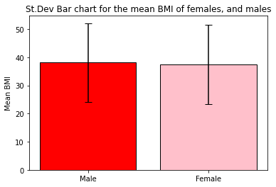

```python
# Plotting a bar chart with the mean BMI per gender, with standard deviation

# list of x-axis labels
x_axis = ["Male", "Female"]

# list of y-axis values parallel to x-axis labels
y_axis = [np.mean(clean_df["BMI"].loc[clean_df["Gender"]=="Male"]), np.mean(clean_df["BMI"].loc[clean_df["Gender"]=="Female"])]

# calculating the standard deviation for the BMIs, in a list that runs parallel to the x-axis labels
std = [(np.std(clean_df["BMI"].loc[clean_df["Gender"]=="Male"])), (np.std(clean_df["BMI"].loc[clean_df["Gender"]=="Male"]))]

# formatting bar chart
plt.bar(x_axis, y_axis, yerr=std, color=['red', 'pink'], ec='black', ecolor='black', capsize=5)
plt.title("St.Dev Bar chart for the mean BMI of females, and males")
plt.ylabel("Mean BMI")

# displaying bar chart
plt.show()
```

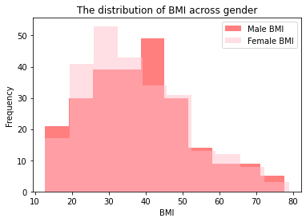

```python
# Plotting a histogram of BMI frequency by gender

# plotting the male histogram
plt.hist(clean_df["BMI"].loc[clean_df["Gender"] == "Male"],  alpha=0.5, label="Male BMI", color='red')

# plotting the female histogram
plt.hist(clean_df["BMI"].loc[clean_df["Gender"] == "Female"],  alpha=0.5, label="Female BMI", color='pink')

# setting histogram parameters
plt.xlabel("BMI")
plt.ylabel("Frequency")
plt.title("The distribution of BMI across gender")
plt.legend(loc="upper right")

# displaying the histogram
plt.show()
```